# music_recsys

## Music Recommendation System Based On Collabrative And Popularity Of Songs

```python
from google.colab import drive
drive.mount('/content/drive')
```

```python
!ls "/content/drive/MyDrive/datasets/final.csv"
```

```
/content/drive/MyDrive/datasets/final.csv
```

```python
# importing required libraries
import pandas as pd
import numpy as np
import tensorflow as tf
from tensorflow import keras
from tensorflow.keras import layers
from pathlib import Path
import matplotlib.pyplot as plt
from IPython.display import display
from sklearn.model_selection import train_test_split
from sklearn.datasets import dump_svmlight_file
import warnings
warnings.filterwarnings('ignore')
```

In below script we have to load preprocessed data

```python
song_df = pd.read_csv('/content/drive/MyDrive/datasets/final.csv')
display(song_df.head())
display(song_df.shape)
```

|  | user_id | song_id | play_count | artist_name | song_name |
| --- | --- | --- | --- | --- | --- |
| 0 | fd50c4007b68a3737fe052d5a4f78ce8aa117f3d | SOBONKR12A58A7A7E0 | 1 | Dwight Yoakam | You're The One |
| 1 | fd50c4007b68a3737fe052d5a4f78ce8aa117f3d | SOEGIYH12A6D4FC0E3 | 1 | Barry Tuckwell/Academy of St Martin-in-the-Fie... | Horn Concerto No. 4 in E flat K495: II. Romanc... |
| 2 | fd50c4007b68a3737fe052d5a4f78ce8aa117f3d | SOFLJQZ12A6D4FADA6 | 1 | Cartola | Tive Sim |
| 3 | fd50c4007b68a3737fe052d5a4f78ce8aa117f3d | SOHTKMO12AB01843B0 | 1 | Lonnie Gordon | Catch You Baby (Steve Pitron & Max Sanna Radio... |
| 4 | fd50c4007b68a3737fe052d5a4f78ce8aa117f3d | SODQZCY12A6D4F9D11 | 1 | Miguel Calo | El Cuatrero |

```
(163206, 5)
```

We need to perform some preprocessing to encode users and songs as integer indices in below script

```python
user_id = song_df['user_id'].unique().tolist()
u2u_encoding = {ele: each for each, ele in enumerate(user_id)}
user_encoded_in_user = {each: ele for each, ele in enumerate(user_id)}
song_Id = song_df['song_id'].unique().tolist()
s2s_encoding = {ele: each for each, ele in enumerate(song_Id)}
song_encoded_in_song = {each: ele for each, ele in enumerate(song_Id)}
song_df['user'] = song_df['user_id'].map(u2u_encoding)
song_df['song'] = song_df['song_id'].map(s2s_encoding)
num_users = len(u2u_encoding)
num_songs = len(s2s_encoding)
song_df['play_count'] = song_df['play_count'].values.astype(np.float32)

# we are using min and max play_count below script
min_play = min(song_df['play_count'])
max_play = max(song_df['play_count'])

# In below we printing no. of users and no. of songs from dataset and we also print min,max play_counts by users.
print("No. of Users: {}, No. of songs:{}, Min play_count:{}, Max play_count: {}".format(num_users, num_songs, min_play, max_play))
```

```
No. of Users: 54227, No. of songs:163206, Min play_count:1.0, Max play_count: 923.0
```

## Prepare Training and Validation Data

```python
play_count_df = song_df.copy()
play_count_df = play_count_df.sample(frac=1, random_state=42)
# Select dependent and Indipendent variables
x = play_count_df[['user','song']].values
# we are normalizing target between 0 and 1. Make it easy to train.
y = play_count_df['play_count'].apply(lambda x: (x -min_play) / (max_play-min_play)).values

# we need to assume that we are training 90% of data and validating on 10% data.

train_indices = int(0.9 * play_count_df.shape[0])
x_train, x_val, y_train, y_val = (x[:train_indices],x[train_indices:],y[:train_indices],y[train_indices:])
```

## Create Model

We embed both users and songs in to 50-dimensional vectors. The model computes a match score between user and song embeddings via a dot product, and adds a per-song and per-user bias. The match score is scaled to the [0, 1] interval via a sigmoid. (since our play_count are normalized to this range)

```python
Embedding_size = 50

class music_recommender(keras.Model):
    def __init__(self, num_users, num_songs, embedding_size, **kwargs):
        super(music_recommender, self).__init__(**kwargs)
        self.num_users = num_users
        self.num_songs = num_songs
        self.embedding_size = embedding_size
        self.user_embedding = layers.Embedding(
            num_users,
            embedding_size,
            embeddings_initializer="he_normal",
            embeddings_regularizer=keras.regularizers.l2(1e-6),
        )
        self.user_bias = layers.Embedding(num_users, 1)
        self.song_embedding = layers.Embedding(
            num_songs,
            embedding_size,
            embeddings_initializer="he_normal",
            embeddings_regularizer=keras.regularizers.l2(1e-6),
        )
        self.song_bias = layers.Embedding(num_songs, 1)

    def call(self, inputs):
        user_vec = self.user_embedding(inputs[:, 0])
        user_bias = self.user_bias(inputs[:, 0])
        song_vec = self.song_embedding(inputs[:, 1])
        song_bias = self.song_bias(inputs[:, 1])
        song_for_dot_users = tf.tensordot(user_vec,song_vec, 2)
        # we are adding all components like including bias
        x =song_for_dot_users + user_bias + song_bias
        # The sigmoid activation forces the rating to between 0 and 1
        return tf.nn.sigmoid(x)

my_model = music_recommender(num_users, num_songs, Embedding_size)
my_model.compile(loss=tf.keras.losses.BinaryCrossentropy(), optimizer=keras.optimizers.Adam(learning_rate=0.001))
```

We need to train our model based on the data split.

```python
history = my_model.fit(
    x=x_train,
    y=y_train,
    batch_size = 64,
    epochs=5,
    verbose=1,
    validation_data=(x_val,y_val),
)
```

## Plot Training And Validation Loss

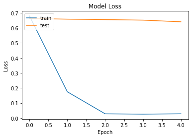

```python
plt.plot(history.history['loss'])
plt.plot(history.history['val_loss'])
plt.title('Model Loss')
plt.ylabel('Loss')
plt.xlabel('Epoch')
plt.legend(['train','test'], loc='upper left')
plt.show()
```

```python
# save model
my_model.save('my_model')
```

```
INFO:tensorflow:Assets written to: my_model/assets
```

## Show top n numbers song recommendations to a user

```python
# choose user and see the top n recommendations
user_id = play_count_df.user_id.sample(1).iloc[0]
user_listned_songs = play_count_df[play_count_df.user_id == user_id]
song_not_listned = song_df[song_df['song_id'].isin(user_listned_songs.song_id.values)]['song_id']
song_not_listned = list(set(song_not_listned).intersection(set(s2s_encoding.keys()))
)
song_not_listned = [[s2s_encoding.get(x)] for x in song_not_listned]
user_encoder = u2u_encoding.get(user_id)
user_song_array = np.hstack(
    ([[user_encoder]] * len(song_not_listned), song_not_listned)
)
play_counts = my_model.predict(user_song_array).flatten()
top_play_count_indices = play_counts.argsort()[-20:][::-1]
recommended_song_ids = [
 song_encoded_in_song.get(song_not_listned[x][0]) for x in top_play_count_indices
]

print("Showing recommendations for user: {}".format(user_id))
print("====" * 9)
print("songs which most played from user")
print("----" * 8)
top_songs_user = (
    user_listned_songs.sort_values(by="play_count", ascending=False)
    .head(8)
    .song_id.values
)
song_df_rows = song_df[song_df["song_id"].isin(top_songs_user)]
for row in song_df_rows.itertuples():
    print(row.song_name, ":", row.artist_name)

print("----" * 8)
print("Top n songs recommendations")
print("----" * 8)
recommended_songs = song_df[song_df["song_id"].isin(recommended_song_ids)]
for row in recommended_songs.itertuples():
    print(row.song_name, ":", row.artist_name)
```

```
Showing recommendations for user: 9c08cfa19d9bb2ea8adf0eaa2e010dad27217db0
====================================
songs which most played from user
--------------------------------
In The Arms Of Perdition : Despised Icon
Freak These Tales : Murs
Devil Woman : Buddy Knox
Space Man : Smash Mouth
Abracadabra : Steve Miller Band
All For Love : Treat
--------------------------------
Top n songs recommendations
--------------------------------
In The Arms Of Perdition : Despised Icon
Freak These Tales : Murs
Devil Woman : Buddy Knox
Space Man : Smash Mouth
Abracadabra : Steve Miller Band
All For Love : Treat
```

```python
my_model.summary()
```

```
Model: "music_recommender"
_________________________________________________________________
Layer (type)                 Output Shape              Param #
=================================================================
embedding (Embedding)        multiple                  2711350
_________________________________________________________________
embedding_1 (Embedding)      multiple                  54227
_________________________________________________________________
embedding_2 (Embedding)      multiple                  8160300
_________________________________________________________________
embedding_3 (Embedding)      multiple                  163206
=================================================================
Total params: 11,089,083
Trainable params: 11,089,083
Non-trainable params: 0
_________________________________________________________________
```

## Music Recommendation System Based on Matrix Factorization

## LATENT FACTORS IN MATRIX FACTORIZATION (MF)

The two decomposed matrix have smaller dimensions compared to the original one. Before applying MF, you need to choose the value for the dimension k of the decomposed matrices. k is known as the number of latent factors. The intuition of this is there are some unknown factors (k) that influence the rating of users to song. The good thing is we don’t have to tell what exactly these factors are. MF will use the value of k to generate 2 matrices, user and song embedding matrices.

```python
matrix_df = pd.read_csv('/content/drive/MyDrive/datasets/final.csv')
matrix_df.head()
```

|  | user_id | song_id | play_count | artist_name | song_name |
| --- | --- | --- | --- | --- | --- |
| 0 | fd50c4007b68a3737fe052d5a4f78ce8aa117f3d | SOBONKR12A58A7A7E0 | 1 | Dwight Yoakam | You're The One |
| 1 | fd50c4007b68a3737fe052d5a4f78ce8aa117f3d | SOEGIYH12A6D4FC0E3 | 1 | Barry Tuckwell/Academy of St Martin-in-the-Fie... | Horn Concerto No. 4 in E flat K495: II. Romanc... |
| 2 | fd50c4007b68a3737fe052d5a4f78ce8aa117f3d | SOFLJQZ12A6D4FADA6 | 1 | Cartola | Tive Sim |
| 3 | fd50c4007b68a3737fe052d5a4f78ce8aa117f3d | SOHTKMO12AB01843B0 | 1 | Lonnie Gordon | Catch You Baby (Steve Pitron & Max Sanna Radio... |
| 4 | fd50c4007b68a3737fe052d5a4f78ce8aa117f3d | SODQZCY12A6D4F9D11 | 1 | Miguel Calo | El Cuatrero |

```python
matrix_df.user_id = matrix_df.user_id.astype('category').cat.codes.values
matrix_df.song_id = matrix_df.song_id.astype('category').cat.codes.values
```

```python
train, test = train_test_split(matrix_df, test_size=0.2)
```

we create train and test sets with 80% and 20% of the original dataset respectively.

```python
n_users, n_songs = len(matrix_df.user_id.unique()), len(matrix_df.song_id.unique())
n_latent_factors = 20
```

Let say we select the number of latent factors as 20.

```python
song_input = keras.layers.Input(shape=[1],name='song_id')
song_embedding = keras.layers.Embedding(n_songs + 1, n_latent_factors, name='song-Embedding')(song_input)
song_vec = keras.layers.Flatten(name='Flattensongs')(song_embedding)
user_input = keras.layers.Input(shape=[1],name='user_id')
user_vec = keras.layers.Flatten(name='FlattenUsers')(keras.layers.Embedding(n_users + 1, n_latent_factors,name='User-Embedding')(user_input))
prod = keras.layers.dot([song_vec, user_vec], axes=1,name='DotProduct')
model = keras.Model([user_input, song_input], prod)
```

We have to compile the model and also monitor two error type, namely, mean absolute error (MAE), and mean squared error (MSE).

```python
model.compile(optimizer='adam', loss='mean_squared_error', metrics=['mae', 'mse'])
```

The model is summarized as below.

```python
model.summary()
```

```
Model: "model"
__________________________________________________________________________________________________
Layer (type)                    Output Shape         Param #     Connected to
==================================================================================================
song_id (InputLayer)            [(None, 1)]          0
__________________________________________________________________________________________________
user_id (InputLayer)            [(None, 1)]          0
__________________________________________________________________________________________________
song-Embedding (Embedding)      (None, 1, 20)        3264140     song_id[0][0]
__________________________________________________________________________________________________
User-Embedding (Embedding)      (None, 1, 20)        1084560     user_id[0][0]
__________________________________________________________________________________________________
Flattensongs (Flatten)          (None, 20)           0           song-Embedding[0][0]
__________________________________________________________________________________________________
FlattenUsers (Flatten)          (None, 20)           0           User-Embedding[0][0]
__________________________________________________________________________________________________
DotProduct (Dot)                (None, 1)            0           Flattensongs[0][0]
                                                                 FlattenUsers[0][0]
==================================================================================================
Total params: 4,348,700
Trainable params: 4,348,700
Non-trainable params: 0
__________________________________________________________________________________________________
```

Now it is time to train our model and log the history:

```python
hist = model.fit([train.user_id, train.song_id], train.play_count, epochs=5, verbose=1)
```

We now evaluate our model. First, we generate the ratings for each user and item pair on the test set and then we calculate the error.

```python
results = model.evaluate((test.user_id, test.song_id), test.play_count, batch_size=5)
```

[output not shown]

## LEARNT EMBEDDING

We have to obtain two embedding matrices for users and songs.

```python
song_embedding_learnt = model.get_layer(name='song-Embedding').get_weights()[0]
pd.DataFrame(song_embedding_learnt).describe()
```

|  | 0 | 1 | 2 | 3 | 4 | 5 | 6 | 7 | 8 | 9 | 10 | 11 | 12 | 13 | 14 | 15 | 16 | 17 | 18 | 19 |
| --- | --- | --- | --- | --- | --- | --- | --- | --- | --- | --- | --- | --- | --- | --- | --- | --- | --- | --- | --- | --- |
| count | 163207.000000 | 163207.000000 | 163207.000000 | 163207.000000 | 163207.000000 | 163207.000000 | 163207.000000 | 163207.000000 | 163207.000000 | 163207.000000 | 163207.000000 | 163207.000000 | 163207.000000 | 163207.000000 | 163207.000000 | 163207.000000 | 163207.000000 | 163207.000000 | 163207.000000 | 163207.000000 |
| mean | 0.000661 | -0.000935 | 0.001327 | -0.000142 | 0.000562 | 0.000134 | 0.000757 | 0.000508 | 0.000419 | 0.000729 | 0.000036 | -0.000218 | -0.000678 | -0.000467 | -0.000112 | -0.000412 | 0.000533 | -0.000306 | 0.000197 | 0.000411 |
| std | 0.129306 | 0.129414 | 0.129536 | 0.129546 | 0.129468 | 0.129536 | 0.129355 | 0.129298 | 0.129467 | 0.129344 | 0.129653 | 0.129617 | 0.129362 | 0.129464 | 0.129357 | 0.129506 | 0.129229 | 0.129428 | 0.129353 | 0.129507 |
| min | -0.207683 | -0.207427 | -0.207700 | -0.207285 | -0.208086 | -0.207373 | -0.207981 | -0.207292 | -0.208085 | -0.207570 | -0.207534 | -0.207540 | -0.207676 | -0.207572 | -0.207425 | -0.207512 | -0.207795 | -0.207524 | -0.207491 | -0.207347 |
| 25% | -0.127100 | -0.128116 | -0.126953 | -0.127799 | -0.127443 | -0.127760 | -0.127049 | -0.127125 | -0.127352 | -0.127223 | -0.127797 | -0.127890 | -0.127710 | -0.127743 | -0.127479 | -0.128119 | -0.126986 | -0.127901 | -0.127483 | -0.127486 |
| 50% | 0.001115 | -0.001742 | 0.002095 | -0.000052 | 0.001397 | -0.000070 | 0.001118 | 0.000717 | 0.000618 | 0.001427 | -0.000119 | -0.000778 | -0.001075 | -0.000958 | -0.000272 | -0.000497 | 0.000716 | -0.000252 | 0.000131 | 0.001013 |
| 75% | 0.127933 | 0.127160 | 0.128386 | 0.127878 | 0.128039 | 0.127886 | 0.127874 | 0.127835 | 0.127874 | 0.127609 | 0.127889 | 0.128092 | 0.127350 | 0.127493 | 0.127598 | 0.127459 | 0.127769 | 0.127498 | 0.127748 | 0.127905 |
| max | 0.207301 | 0.207764 | 0.207472 | 0.207624 | 0.207536 | 0.207381 | 0.207498 | 0.207495 | 0.207208 | 0.207885 | 0.207942 | 0.207506 | 0.207682 | 0.207624 | 0.207823 | 0.207513 | 0.207641 | 0.207496 | 0.207339 | 0.207683 |

```python
user_embedding_learnt = model.get_layer(name='User-Embedding').get_weights()[0]
```

```python
def recommend_songs(user_id, number_of_songs=5):
  songs = user_embedding_learnt[user_id]@song_embedding_learnt.T
  sids = np.argpartition(songs, -number_of_songs)[-number_of_songs:]
  return sids
```

```python
recommend_songs(user_id=12)
```

```
array([120288,  37806, 132058,  57575,  85104])
```

In Above script we have achived song recommendation based on matrix factorization.

## CONCLUSION

A simple recommender system with matrix factorization using Keras. Nevertheless, embedding matrices have some negative values. There are some applications which require that the learnt embeddings be non-negative.